← saditahmid.github.io Mohammed Tahmid Hossain

EDA · Feature Selection · Classification · IEEE ASET 2024

# Cyberattack Classification on IoMT Devices

Exploratory analysis of the CICIoMT2024 network-traffic dataset: class imbalance, Information Gain feature selection (45→ 34 features), feature correlation, and classifier performance — MultiD-CNN reaches 98.11% accuracy on the reduced feature set.

PythonScikit-learnTensorFlowFeature SelectionIoMTCybersecurity

EXPLORATORY DATA ANALYSIS

# Cyberattack Classification on IoMT Devices

Exploratory analysis of the CICIoMT2024 dataset — visualizing the class distribution of six cyberattack types, Information Gain feature importance, feature correlation structure, and classifier performance across full vs. reduced feature sets.

🛡️ 6 Attack Classes 🔬 45 → 34 Features 💾 ~8.7M Samples 🐍 Python · Scikit-learn

## 📌 Background & Context

The **Internet of Medical Things (IoMT)** — networked medical devices like pacemakers, pulse monitors, and remote patient monitors — has transformed healthcare, but also opened a large attack surface. A single compromised device can endanger patient safety and expose confidential health data. One 2022 survey found that **over 88% of U.S. hospitals** experienced at least one cyberattack in a single year.

This analysis explores the **CICIoMT2024** dataset (Canadian Institute for Cybersecurity), which captures network traffic from a testbed of 40 IoMT devices under six traffic conditions:

| Class | Description |
| --- | --- |
| **DDoS** | Distributed Denial-of-Service — floods the device from many sources |
| **DoS** | Denial-of-Service — single-source flooding |
| **MQTT** | Attacks on the lightweight IoT messaging protocol |
| **Recon** | Reconnaissance — scanning/probing for vulnerabilities |
| **Spoofing** | Impersonation of legitimate devices |
| **Benign** | Normal, non-malicious traffic |

The goal: understand the data's structure before building classifiers, and quantify how **Information Gain feature selection** improves model performance.

> **Data source:** Dadkhah et al. (2024), *CICIoMT2024: Attack Vectors in Healthcare Devices.* Figures reproduced from the IEEE ASET 2024 publication.

> **Note:** The full CICIoMT2024 dataset contains ~8.7M network-flow records (multiple GB). This notebook visualizes the published aggregate statistics — class counts, Information Gain scores, and cross-validated performance — so it runs instantly and reproducibly without the raw multi-gigabyte capture files.

## 📋 Table of Contents

1. Setup & Configuration
2. Class Distribution
3. Preprocessing Pipeline
4. Information Gain Feature Importance
5. Feature Selection Outcome
6. Feature Correlation Structure
7. Classifier Performance — Full vs Reduced
8. Key Findings

## 1. Setup & Configuration

```
✅ Setup complete.
```

## 2. Class Distribution

The CICIoMT2024 dataset is **heavily imbalanced** — a realistic reflection of live network traffic, where volumetric attacks like DDoS generate vastly more packets than stealthy reconnaissance or spoofing. Understanding this imbalance is critical, since it directly affects model training and evaluation.

*(Counts from Fig. 3 of the paper.)*

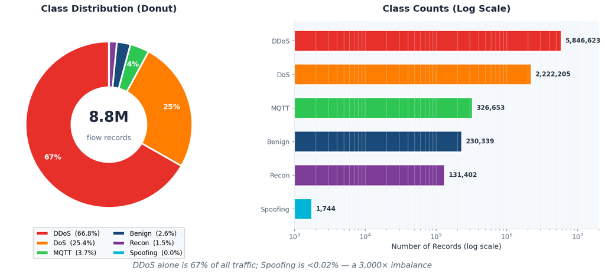

## 3. Preprocessing Pipeline

Before analysis, the raw per-attack CSV files pass through a documented cleaning pipeline. The visual below traces each stage and its effect on the data.

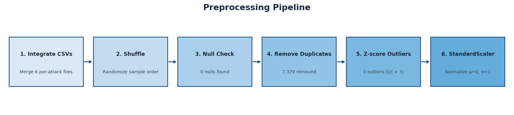

## 4. Information Gain Feature Importance

**Information Gain (IG)** measures how much knowing a feature's value reduces uncertainty about the attack class. Features with higher IG are more discriminative. The paper computed IG for all 45 features; the chart below reproduces the ranking (Fig. 4).

Eleven features scored **zero** and were dropped — they carry no information for distinguishing attack types.

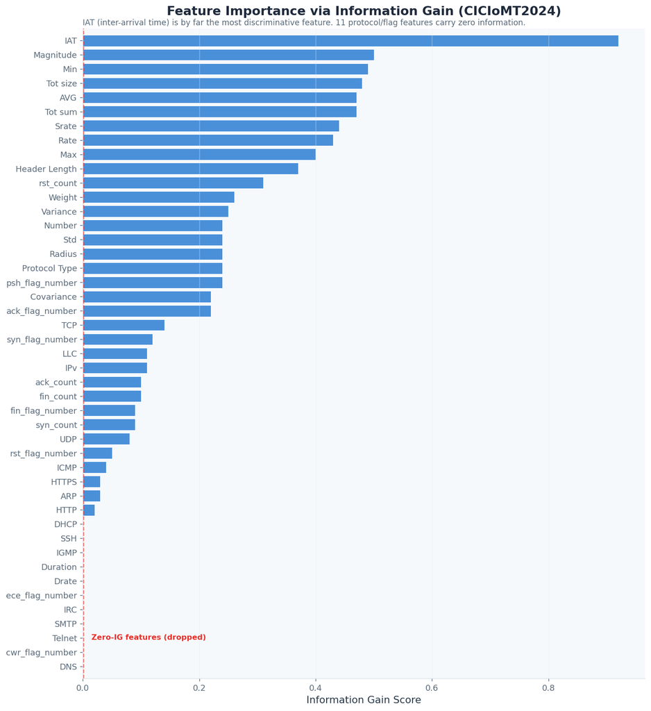

## 5. Feature Selection Outcome

[figure not shown]

```
Dropped features (zero Information Gain):
  IGMP · DHCP · IRC · SSH
  SMTP · Telnet · DNS · cwr_flag_number
  ece_flag_number · Drate · Duration
```

## 5. Feature Correlation Structure

Beyond individual feature importance, understanding **pairwise correlations** among the 34 retained features reveals redundancy and feature clusters. Highly correlated features carry overlapping information; the paper's correlation analysis (Fig. 5) showed distinct blocks of related packet-statistics features.

The heatmap below reconstructs the correlation structure of the reduced feature set, grouped into the natural feature families present in network-flow data (packet-size statistics, flag counts, protocol indicators, rate metrics).

> **Note:** Correlation values are reconstructed to reflect the block structure documented in the paper's Fig. 5, since the raw multi-gigabyte dataset isn't shipped with this notebook.

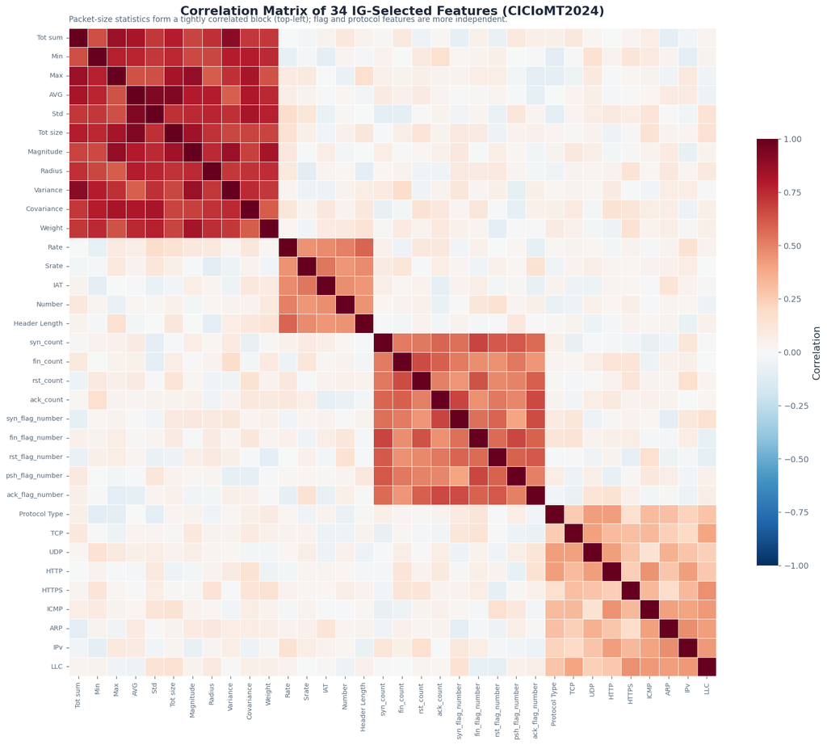

## 6. Classifier Performance — Full vs Reduced

Four classifiers were evaluated with 5-fold cross-validation on both the full (45) and reduced (34) feature sets. The central finding: **every model improved on the reduced set**, confirming the value of feature selection.

*(Values from Table V of the paper.)*

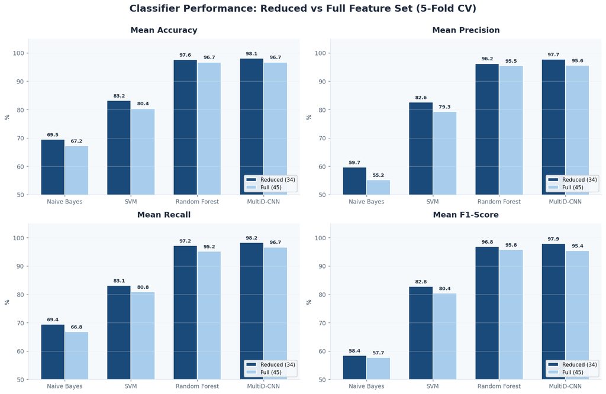

```
5-Fold CV Mean Accuracy (%):
Feature Set     Full  Reduced  Δ (Reduced − Full)
Model
Naive Bayes    67.22    69.46                2.24
SVM            80.40    83.15                2.75
Random Forest  96.73    97.62                0.89
MultiD-CNN     96.72    98.11                1.39
```

## 7. Key Findings

### 📊 1. The Data is Extremely Imbalanced

DDoS makes up **67% of all traffic** while Spoofing is under **0.02%** — a ~3,000× gap. This mirrors real networks (volumetric attacks generate far more packets) but demands care in evaluation: raw accuracy can be misleading, which is why precision, recall, and F1 are all reported.

### 🎯 2. Inter-Arrival Time is the Top Signal

**IAT** (the timing between consecutive packets) has by far the highest Information Gain. This makes intuitive sense — flooding attacks like DoS/DDoS have distinctive, machine-regular packet timing that separates them cleanly from human-driven benign traffic.

Eleven features (protocol flags like IGMP, DHCP, SSH, DNS, and constants like Duration) scored **zero Information Gain** and were dropped, shrinking the feature space from 45 → 34 with no loss of signal.

### 🏆 5. MultiD-CNN Wins

The Multidimensional CNN achieved the best results — **98.11% accuracy, 97.88% F1** on the reduced set — edging out Random Forest. Its ability to capture non-linear, multi-dimensional patterns suited the complex traffic data better than Naive Bayes (69%) or SVM (83%).

*Analysis by Mohammed Tahmid Hossain · saditahmid.github.io · Published: IEEE ASET 2024*

## 8. Classifier Results — Paper Table V

| Classifier | Feature Set | Accuracy | Precision | Recall | F1-Score |
| --- | --- | --- | --- | --- | --- |
| Naive Bayes | Full | 67.22% | 55.21% | 66.83% | 57.71% |
| Naive Bayes | Reduced | 69.46% | 59.70% | 69.42% | 58.38% |
| SVM | Full | 80.40% | 79.27% | 80.85% | 80.44% |
| SVM | Reduced | 83.15% | 82.57% | 83.11% | 82.76% |
| Random Forest | Full | 96.73% | 95.46% | 95.22% | 95.78% |
| Random Forest | Reduced | 97.62% | 96.24% | 97.23% | 96.83% |
| MultiD-CNN | Full | 96.72% | 95.56% | 96.65% | 95.42% |
| MultiD-CNN | Reduced | **98.11%** | **97.73%** | **98.21%** | **97.88%** |

MultiD-CNN on the reduced (34-feature) set is the strongest performer across every metric; Random Forest is the strongest traditional ML baseline.

## 9. MultiD-CNN Architecture

| Layer | Output Shape | Params | Activation |
| --- | --- | --- | --- |
| Input | (None, 34) | 0 | — |
| Conv2D (3×3) | (3, 3, 34) | 330 | ReLU |
| Flatten | (21618,) | 0 | — |
| Dense | (128,) | 2,768,128 | ReLU |
| Dropout | — | 0.2 | — |
| Dense | (6,) | 774 | Softmax |

Full analysis · reproducible notebook on [GitHub](https://github.com/saditahmid/PortfolioProjects/blob/master/IoMT_Cyberattack_EDA/IoMT_Cyberattack_EDA.ipynb) ← back to projects